# icda_explained

Alokesh Manna

2024-10-04

```r
#install.packages("devtools")
library(devtools)
#install_github("presnell/icda")
library(icda)
```

Cola preference

```r
dbinom(0, 3, .6)
```

```
## [1] 0.064
```

```r
dbinom(1, 3, .6)
```

```
## [1] 0.288
```

```r
dbinom(0:3, 3, .6)
```

```
## [1] 0.064 0.288 0.432 0.216
```

```r
cbind(0:3, dbinom(0:3, 3, .6))
```

```
##      [,1]  [,2]
## [1,]    0 0.064
## [2,]    1 0.288
## [3,]    2 0.432
## [4,]    3 0.216
```

```r
###################################################
### code chunk number 9: icda-notes.Rnw:490-492
###################################################
```

1. How to plot a PMF? type = “h”

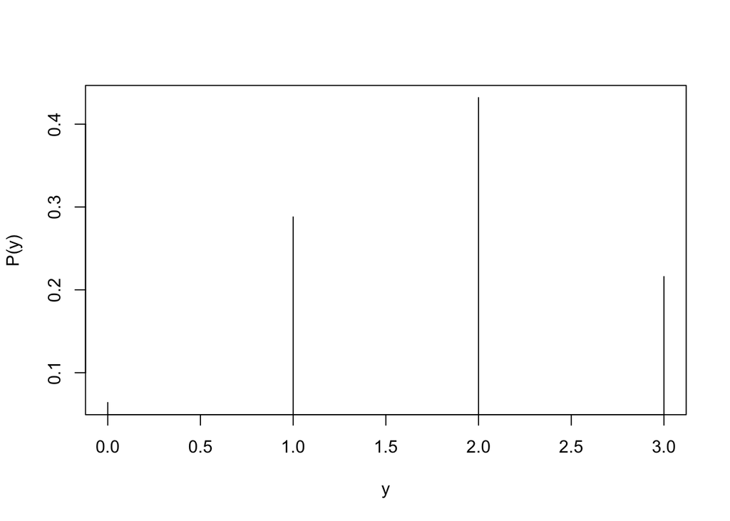

```r
plot(0:3, dbinom(0:3, 3, .6), type = "h",
     xlab = "y", ylab = "P(y)")
```

2. Plot a overall distribution

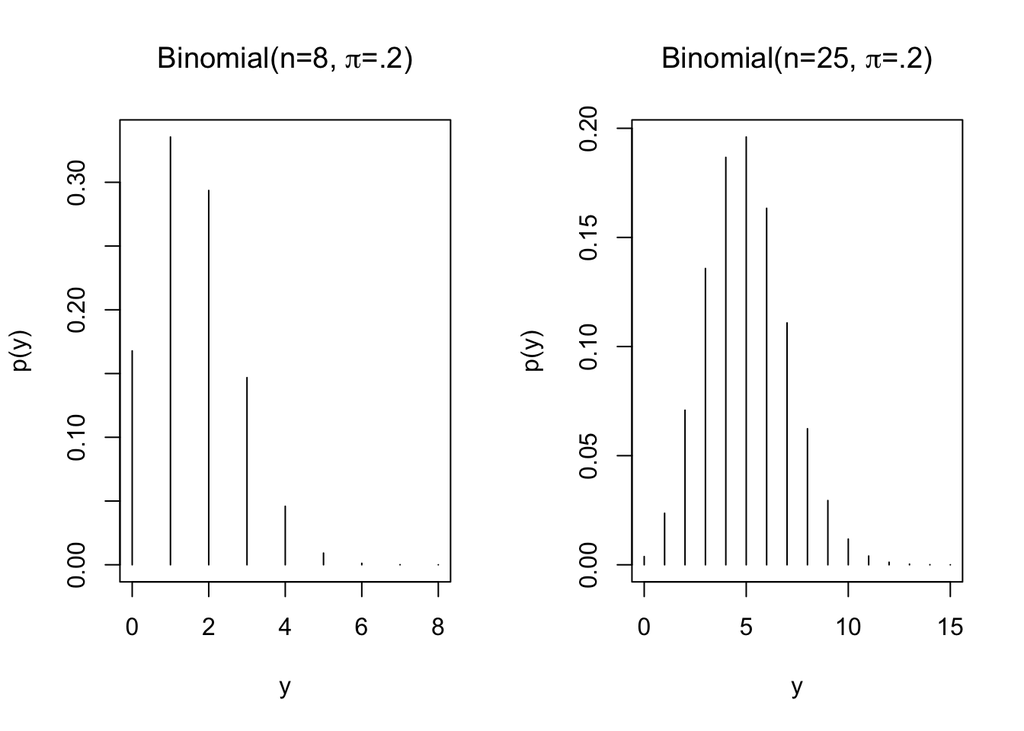

```r
opar <- par(mfrow=c(1,2))
plot(0:8, dbinom(0:8,8,.2), type="h", xlab="y", ylab="p(y)",
main=expression(paste("Binomial(n=8, ",pi,"=.2)")))
plot(0:15, dbinom(0:15,25,.2), type="h", xlab="y", ylab="p(y)",
main=expression(paste("Binomial(n=25, ",pi,"=.2)")))
```

```r
par(opar)
```

3. A curve? curve has an argument as x. Also we want to show different segments.

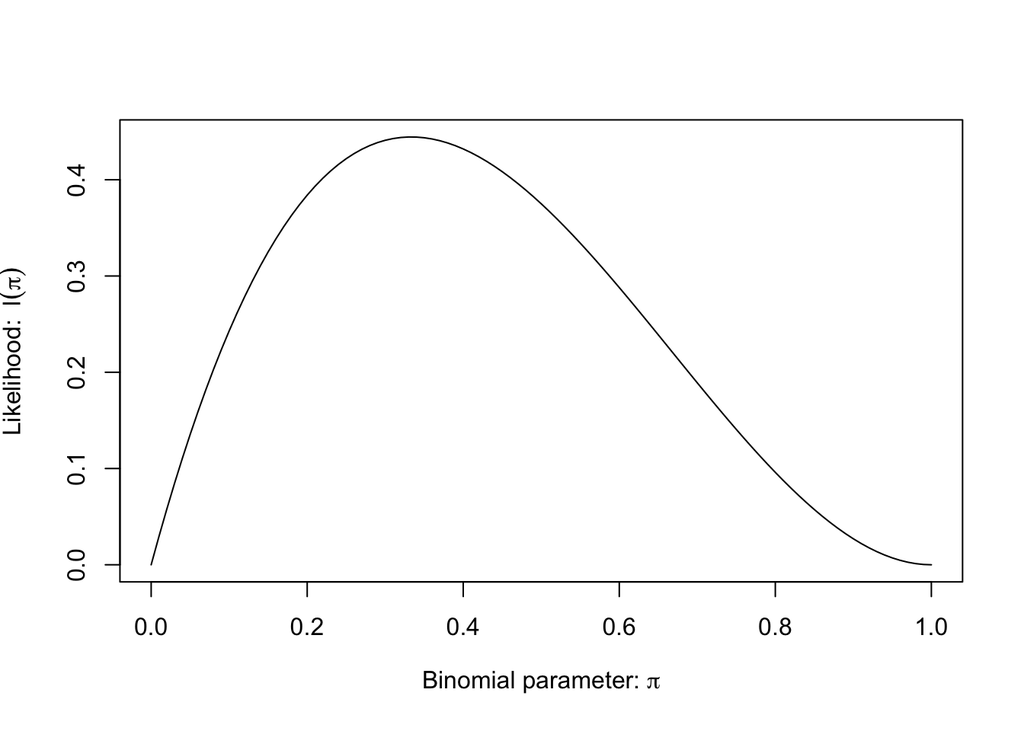

```r
curve(dbinom(1,3,x), xlim = c(0,1),
xlab=expression(paste("Binomial parameter: ",pi)),
ylab=expression(paste("Likelihood:  ", l(pi))))
```

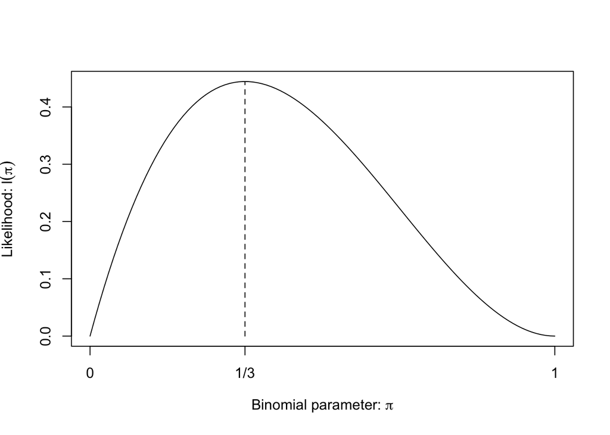

```r
curve(dbinom(1,3,x), xlim = c(0,1), xaxt="n",
      xlab=expression(paste("Binomial parameter: ",pi)),
      ylab=expression(paste("Likelihood: ", l(pi))))
axis(1, at=c(0,1/3,1), labels=c("0","1/3","1"))
segments(1/3, 0, 1/3, dbinom(1, 3, 1/3), lty=2)
```

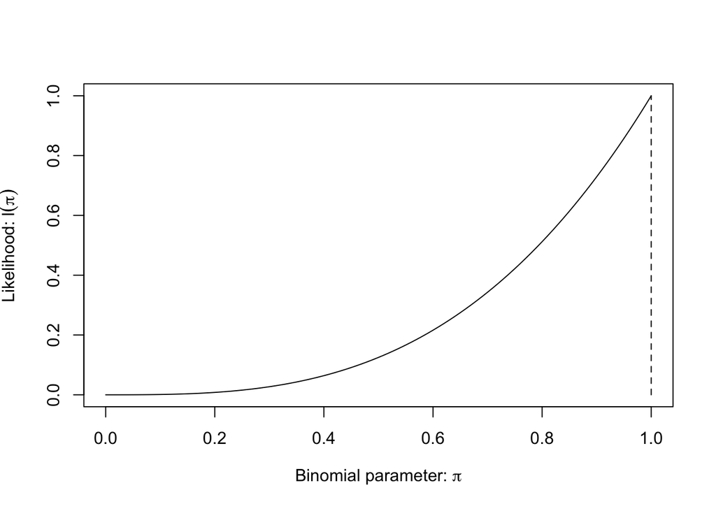

```r
curve(dbinom(3,3,x), xlim = c(0,1),
      xlab=expression(paste("Binomial parameter: ",pi)),
      ylab=expression(paste("Likelihood: ", l(pi))))
segments(1, 0, 1, dbinom(3, 3, 1), lty=2)
```

4. Null: x/n = .5 if there is only one group.

prop.test(x, n, p = NULL, alternative = c(“two.sided”, “less”, “greater”), conf.level = 0.95, correct = TRUE)

Continuity correction is used only if it does not exceed the difference between sample and null proportions in absolute value.

```r
prop.test(0,20)
```

```
##
##  1-sample proportions test with continuity correction
##
## data:  0 out of 20, null probability 0.5
## X-squared = 18.05, df = 1, p-value = 2.152e-05
## alternative hypothesis: true p is not equal to 0.5
## 95 percent confidence interval:
##  0.0000000 0.2004533
## sample estimates:
## p
## 0
```

For very small n, do inference using the exact binomial sampling distribution of the data, instead of the normal approximation.

R Functions for Simple Binomial Tests and CI

```r
binom.test(0,20)
```

```
##
##  Exact binomial test
##
## data:  0 and 20
## number of successes = 0, number of trials = 20, p-value = 1.907e-06
## alternative hypothesis: true probability of success is not equal to 0.5
## 95 percent confidence interval:
##  0.0000000 0.1684335
## sample estimates:
## probability of success
##                      0
```

5. contingency table from page 35 https://huskyct.uconn.edu/ultra/courses/_150350_1/cl/outline

```r
phs <- matrix(c(189, 10845, 104, 10933), ncol = 2, byrow = TRUE)
dimnames(phs) <-
  list(Group = c("Placebo","Aspirin"), MI = c("Y", "N"))
```

```r
phs
```

```
##          MI
## Group       Y     N
##   Placebo 189 10845
##   Aspirin 104 10933
```

If you get a positive result, more relevant to you is Pr(X = 1|Y = 1). If disease is relatively rare, this may be low even if sensitivity and specificity are high.

Statistical independence test: 1. direct method: $SE(p1 − p2) = \sqrt{p1(1 − p1)/n1+ p2(1 − p2)/n2}$ use the normality and CI approach. If $p1 − p2+/-SE(p1 − p2)$ includes 0, no significant difference.

2.$\text{odd ratio} =(π1/(1 − π1))/(π2/(1 − π2))=π1(1 − π2)/π2(1 − π1)$ Test for $\text{odd ratio}=1$ or not! $SE(log odd ratio) = \sqrt{1/n11+1/n12+1/n21+1/n22}$ So now use the CI $log odd ratio+/-1.96 SE$

3. Chi square independence test. df:(I-1)(J-1). one sided test.
4. Liklihood ration test. $-2log(\text{liklihood under} H_{0}/\text{liklihood under} H_{1})$. df:(I-1)(J-1). one sided test.

```r
pag.tab <- matrix(c(762, 484, 327, 239, 468, 477), nrow=2)
dimnames(pag.tab) <-
  list(Gender=c("Female","Male"),
       Party=c("Democrat","Independent","Republican"))
pag.tab <- as.table(pag.tab)
pag.tab
```

```
##         Party
## Gender   Democrat Independent Republican
##   Female      762         327        468
##   Male        484         239        477
```

```r
###################################################
### code chunk number 36: icda-notes.Rnw:1965-1967
###################################################
pag.df <- as.data.frame(pag.tab)
pag.df
```

```
##   Gender       Party Freq
## 1 Female    Democrat  762
## 2   Male    Democrat  484
## 3 Female Independent  327
## 4   Male Independent  239
## 5 Female  Republican  468
## 6   Male  Republican  477
```

```r
###################################################
### code chunk number 37: icda-notes.Rnw:1977-1982
###################################################
pag.df <-
  expand.grid(Gender=c("Female","Male"),
             Party=c("Democrat","Independent","Republican"))
pag.df
```

```
##   Gender       Party
## 1 Female    Democrat
## 2   Male    Democrat
## 3 Female Independent
## 4   Male Independent
## 5 Female  Republican
## 6   Male  Republican
```

```r
pag.df$Freq <- c(762, 484, 327, 239, 468, 477)


###################################################
### code chunk number 38: icda-notes.Rnw:1990-1992
###################################################
pag.df
```

```
##   Gender       Party Freq
## 1 Female    Democrat  762
## 2   Male    Democrat  484
## 3 Female Independent  327
## 4   Male Independent  239
## 5 Female  Republican  468
## 6   Male  Republican  477
```

```r
xtabs(Freq ~ Gender + Party, data=pag.df)
```

```
##         Party
## Gender   Democrat Independent Republican
##   Female      762         327        468
##   Male        484         239        477
```

```r
###################################################
### code chunk number 39: icda-notes.Rnw:2008-2009 (eval = FALSE)
###################################################
## pag.df <- read.table("Data/pag.txt", header=TRUE)
```

```r
pag.tab
```

```
##         Party
## Gender   Democrat Independent Republican
##   Female      762         327        468
##   Male        484         239        477
```

```r
margin.table(pag.tab, 1)
```

```
## Gender
## Female   Male
##   1557   1200
```

```r
margin.table(pag.tab, 2)
```

```
## Party
##    Democrat Independent  Republican
##        1246         566         945
```

```r
###################################################
### code chunk number 42: icda-notes.Rnw:2042-2043
###################################################
addmargins(pag.tab)
```

```
##         Party
## Gender   Democrat Independent Republican  Sum
##   Female      762         327        468 1557
##   Male        484         239        477 1200
##   Sum        1246         566        945 2757
```

```r
###################################################
### code chunk number 43: icda-notes.Rnw:2054-2056
###################################################
prop.table(pag.tab)
```

```
##         Party
## Gender     Democrat Independent Republican
##   Female 0.27638738  0.11860718 0.16974973
##   Male   0.17555314  0.08668843 0.17301415
```

```r
round(prop.table(pag.tab), 3)
```

```
##         Party
## Gender   Democrat Independent Republican
##   Female    0.276       0.119      0.170
##   Male      0.176       0.087      0.173
```

```r
###################################################
### code chunk number 44: icda-notes.Rnw:2066-2067
###################################################
prop.table(pag.tab, 1) # row wise proportion
```

```
##         Party
## Gender    Democrat Independent Republican
##   Female 0.4894027   0.2100193  0.3005780
##   Male   0.4033333   0.1991667  0.3975000
```

```r
###################################################
### code chunk number 45: icda-notes.Rnw:2071-2072
###################################################
prop.table(pag.tab, 2)# column wise proportion
```

```
##         Party
## Gender    Democrat Independent Republican
##   Female 0.6115570   0.5777385  0.4952381
##   Male   0.3884430   0.4222615  0.5047619
```

chisquare test

```r
chisq.test(pag.tab)
```

```
##
##  Pearson's Chi-squared test
##
## data:  pag.tab
## X-squared = 30.07, df = 2, p-value = 2.954e-07
```

```r
###################################################
### code chunk number 47: icda-notes.Rnw:2091-2096
###################################################
pag.chisq <- chisq.test(pag.tab)
names(pag.chisq)
```

```
## [1] "statistic" "parameter" "p.value"   "method"    "data.name" "observed"
## [7] "expected"  "residuals" "stdres"
```

```r
pag.chisq$statistic
```

```
## X-squared
##  30.07015
```

```r
pag.chisq$parameter
```

```
## df
##  2
```

```r
pag.chisq$p.value
```

```
## [1] 2.953589e-07
```

```r
###################################################
pag.chisq$observed
```

```
##         Party
## Gender   Democrat Independent Republican
##   Female      762         327        468
##   Male        484         239        477
```

```r
pag.chisq$expected
```

```
##         Party
## Gender   Democrat Independent Republican
##   Female 703.6714    319.6453   533.6834
##   Male   542.3286    246.3547   411.3166
```

```r
with(pag.chisq, sum((observed - expected)^2/expected))
```

```
## [1] 30.07015
```

we can check the residuals and standarized residuals

```r
###################################################
pag.chisq$residuals
```

```
##         Party
## Gender     Democrat Independent Republican
##   Female  2.1988558   0.4113702 -2.8432397
##   Male   -2.5046695  -0.4685829  3.2386734
```

```r
###################################################
### code chunk number 50: icda-notes.Rnw:2125-2126
###################################################
pag.chisq$stdres
```

```
##         Party
## Gender     Democrat Independent Republican
##   Female  4.5020535   0.6994517 -5.3159455
##   Male   -4.5020535  -0.6994517  5.3159455
```

Now one can check for 72-75 with 3*3 table.

Exact Inference for Small Samples

2 × 2 Case: Fisher’s Exact Test: when row and column total are fixed we should use hypergeometric distribution.

1. Lady tasting tea:The lady is told that milk was poured first in 4 cups and tea first in the other 4. Order of tasting is randomized. Asked to identify the 4 cups with milk poured first.

```r
x <- cbind(0:4, round(dhyper(0:4, 4, 4, 4), 3))
colnames(x) <- c("$n_{11}$", "$P(n_{11})$")
#latex(x, file="", first.hline.double=FALSE)


###################################################
### code chunk number 57: icda-notes.Rnw:2459-2466
###################################################
TeaTasting <-
  matrix(c(3, 1, 1, 3),
         nrow = 2,
         dimnames = list(Truth = c("Milk", "Tea"),
           Guess = c("Milk", "Tea")))
TeaTasting <- as.table(TeaTasting)
TeaTasting
```

```
##       Guess
## Truth  Milk Tea
##   Milk    3   1
##   Tea     1   3
```

fisher test used odd ratio.

```r
fisher.test(TeaTasting, alternative = "greater")
```

```
##
##  Fisher's Exact Test for Count Data
##
## data:  TeaTasting
## p-value = 0.2429
## alternative hypothesis: true odds ratio is greater than 1
## 95 percent confidence interval:
##  0.3135693       Inf
## sample estimates:
## odds ratio
##   6.408309
```

```r
###################################################
### code chunk number 58: icda-notes.Rnw:2486-2487
###################################################
fisher.test(TeaTasting, alternative = "two.sided")
```

```
##
##  Fisher's Exact Test for Count Data
##
## data:  TeaTasting
## p-value = 0.4857
## alternative hypothesis: true odds ratio is not equal to 1
## 95 percent confidence interval:
##    0.2117329 621.9337505
## sample estimates:
## odds ratio
##   6.408309
```

```r
###################################################
### code chunk number 59: icda-notes.Rnw:2511-2513
###################################################
#sattab
#fisher.test(sattab)
```

This can be extended to more than 2*2 table!

```r
library(icda)
data(deathpenalty)
deathpenalty <-
  transform(deathpenalty,
            DeathPenalty = relevel(DeathPenalty, "Yes"),
            Defendant = relevel(Defendant, "White"),
            Victim = relevel(Victim, "White"))
deathpenalty
```

```
##   DeathPenalty Defendant Victim Freq
## 1          Yes     White  White   53
## 2           No     White  White  414
## 3          Yes     Black  White   11
## 4           No     Black  White   37
## 5          Yes     White  Black    0
## 6           No     White  Black   16
## 7          Yes     Black  Black    4
## 8           No     Black  Black  139
```

Make a table from the data

```r
dp <- xtabs(Freq ~ Victim + Defendant + DeathPenalty,
            data=deathpenalty)
dp
```

```
## , , DeathPenalty = Yes
##
##        Defendant
## Victim  White Black
##   White    53    11
##   Black     0     4
##
## , , DeathPenalty = No
##
##        Defendant
## Victim  White Black
##   White   414    37
##   Black    16   139
```

Make it so that it looks better.

```r
dpflat <- ftable(DeathPenalty ~ Victim + Defendant,
                 data=dp)
dpflat
```

```
##                  DeathPenalty Yes  No
## Victim Defendant
## White  White                   53 414
##        Black                   11  37
## Black  White                    0  16
##        Black                    4 139
```

```r
round(100*prop.table(dpflat,1), 1)
```

```
##                  DeathPenalty   Yes    No
## Victim Defendant
## White  White                   11.3  88.7
##        Black                   22.9  77.1
## Black  White                    0.0 100.0
##        Black                    2.8  97.2
```

These are called partial tables. They control for Z (hold it constant). Y = death penalty (response var.) X = defendant’s race (explanatory) Z = victim’s race (control var.) The (estimated) conditional odds ratios are:

```r
dpmargin <- xtabs(Freq ~ Defendant + DeathPenalty,
                  data=deathpenalty)
dpmargin
```

```
##          DeathPenalty
## Defendant Yes  No
##     White  53 430
##     Black  15 176
```

The (estimated) conditional odds ratios are: Z = white : odds XY(1) =(53 × 37)/(414 × 11)= 0.43 (0.42 after add .5 to all cells) Z = black : odds XY(2) = (0 × 139)/(16 × 4)= 0 (0.94 after add .5 to all cells) Controlling for victim’s race, odds of receiving death penalty were lower for white defendants than for black defendants.

2. Simpson’s Paradox:

Now ignore race! the odds ratio is 1.45

can be dangerous to “collapse” contingency tables

3. Conditional Independence

X and Y are conditionally independent given Z if they are independent in each partial table.

Null: all odd ratio are 1.

1. Cochran-Mantel-Haenszel (CMH) Test

```r
# Create a 3-way contingency table
data <- array(c(23, 12, 18, 25, 16, 28, 30, 10, 15, 35, 20, 40),
              dim = c(2, 2, 3),
              dimnames = list(A = c("Yes", "No"),
                              B = c("Yes", "No"),
                              C = c("Group1", "Group2", "Group3")))

# Print the contingency table
print(data)
```

```
## , , C = Group1
##
##      B
## A     Yes No
##   Yes  23 18
##   No   12 25
##
## , , C = Group2
##
##      B
## A     Yes No
##   Yes  16 30
##   No   28 10
##
## , , C = Group3
##
##      B
## A     Yes No
##   Yes  15 20
##   No   35 40
```

```r
# Conduct the CMH test for conditional independence between A and B, controlling for C
cmh_result <- mantelhaen.test(data)

# Print the result
print(cmh_result)
```

```
##
##  Mantel-Haenszel chi-squared test with continuity correction
##
## data:  data
## Mantel-Haenszel X-squared = 0.94572, df = 1, p-value = 0.3308
## alternative hypothesis: true common odds ratio is not equal to 1
## 95 percent confidence interval:
##  0.4769796 1.2428266
## sample estimates:
## common odds ratio
##          0.769937
```

Can also be extended to generalized linear model:

```r
# Example contingency table (3-way)
data <- array(c(23, 12, 18, 25, 16, 28, 30, 10, 15, 35, 20, 40),
              dim = c(2, 2, 3),
              dimnames = list(A = c("Yes", "No"),
                              B = c("Yes", "No"),
                              C = c("Group1", "Group2", "Group3")))

# Convert to table object
table_data <- as.table(data)

# Load the necessary library
library(MASS)

# Fit the log-linear model without interaction A:B
model <- loglm(~ A + B + C + A:C + B:C, data = table_data)

# Print the summary
summary(model)
```

```
## Formula:
## ~A + B + C + A:C + B:C
## attr(,"variables")
## list(A, B, C)
## attr(,"factors")
##   A B C A:C B:C
## A 1 0 0   1   0
## B 0 1 0   0   1
## C 0 0 1   1   1
## attr(,"term.labels")
## [1] "A"   "B"   "C"   "A:C" "B:C"
## attr(,"order")
## [1] 1 1 1 2 2
## attr(,"intercept")
## [1] 1
## attr(,"response")
## [1] 0
## attr(,".Environment")
## <environment: R_GlobalEnv>
##
## Statistics:
##                       X^2 df     P(> X^2)
## Likelihood Ratio 17.61226  3 0.0005287251
## Pearson          17.16815  3 0.0006526352
```

Generalized linear model:

The same ML (maximum likelihood) fitting procedure applies to all GLMs. It is the basis of the glm() function in R and of proc genmod in SAS.

```r
data(malformation)
malformation
```

```
##    Alcohol Malformation  Freq
## 1      0.0      Present    48
## 2      0.0       Absent 17066
## 3      0.5      Present    38
## 4      0.5       Absent 14464
## 5      1.5      Present     5
## 6      1.5       Absent   788
## 7      4.0      Present     1
## 8      4.0       Absent   126
## 9      7.0      Present     1
## 10     7.0       Absent    37
```

```r
malform.tab <- xtabs(Freq ~ Alcohol + Malformation,
                     data=malformation)
malform.tab
```

```
##        Malformation
## Alcohol Absent Present
##     0    17066      48
##     0.5  14464      38
##     1.5    788       5
##     4      126       1
##     7       37       1
```

```r
round(100*prop.table(malform.tab, 1), 2)
```

```
##        Malformation
## Alcohol Absent Present
##     0    99.72    0.28
##     0.5  99.74    0.26
##     1.5  99.37    0.63
##     4    99.21    0.79
##     7    97.37    2.63
```

```r
###################################################
### code chunk number 69: malformation.3
###################################################
library(reshape2)
malformwide <- dcast(malformation,
                   Alcohol ~ Malformation,
                   value.var="Freq")
malformwide
```

```
##   Alcohol Absent Present
## 1     0.0  17066      48
## 2     0.5  14464      38
## 3     1.5    788       5
## 4     4.0    126       1
## 5     7.0     37       1
```

```r
###################################################
### code chunk number 70: malformation.4
###################################################
malform.lin <-
  glm(cbind(Present,Absent) ~ Alcohol,
      family=binomial(link=make.link("identity")),
      data=malformwide)
malformwide <-
  transform(malformwide, Total = Present + Absent)
malform.lin.alt <-
  glm(Present/Total ~ Alcohol, weights=Total,
      family=binomial(link=make.link("identity")),
      data=malformwide)
coef(malform.lin)
```

```
## (Intercept)     Alcohol
## 0.002547627 0.001087189
```

```r
 summary(malform.lin)
```

```
##
## Call:
## glm(formula = cbind(Present, Absent) ~ Alcohol, family = binomial(link = make.link("identity")),
##     data = malformwide)
##
## Coefficients:
##              Estimate Std. Error z value Pr(>|z|)
## (Intercept) 0.0025476  0.0003523   7.232 4.77e-13 ***
## Alcohol     0.0010872  0.0008324   1.306    0.192
## ---
## Signif. codes:  0 '***' 0.001 '**' 0.01 '*' 0.05 '.' 0.1 ' ' 1
##
## (Dispersion parameter for binomial family taken to be 1)
##
##     Null deviance: 6.2020  on 4  degrees of freedom
## Residual deviance: 2.9795  on 3  degrees of freedom
## AIC: 25.606
##
## Number of Fisher Scoring iterations: 10
```

```r
###################################################
malcoef.lin <- summary(malform.lin)$coefficients


###################################################
### code chunk number 74: malform.6
###################################################
malform.logit <- glm(cbind(Present,Absent) ~ Alcohol,
                     family=binomial, data=malformwide)


###################################################
### code chunk number 75: malform.7 (eval = FALSE)
###################################################
## summary(malform.logit)


###################################################
### code chunk number 76: icda-notes.Rnw:3016-3017
###################################################
summary(malform.logit)
```

```
##
## Call:
## glm(formula = cbind(Present, Absent) ~ Alcohol, family = binomial,
##     data = malformwide)
##
## Coefficients:
##             Estimate Std. Error z value Pr(>|z|)
## (Intercept)  -5.9605     0.1154 -51.637   <2e-16 ***
## Alcohol       0.3166     0.1254   2.523   0.0116 *
## ---
## Signif. codes:  0 '***' 0.001 '**' 0.01 '*' 0.05 '.' 0.1 ' ' 1
##
## (Dispersion parameter for binomial family taken to be 1)
##
##     Null deviance: 6.2020  on 4  degrees of freedom
## Residual deviance: 1.9487  on 3  degrees of freedom
## AIC: 24.576
##
## Number of Fisher Scoring iterations: 4
```

```r
malcoef.logit <- summary(malform.logit)$coefficients
maldel <- malformwide
maldel[5,c("Present","Total")] <- c(0,37)
maldel.logit <-
  glm(Present/Total ~ Alcohol, weights=Total,
      family=binomial(link="logit"),
      data=maldel)
maldel.pval <- summary(maldel.logit)$coefficients[2,4]
```

Upto slide 110

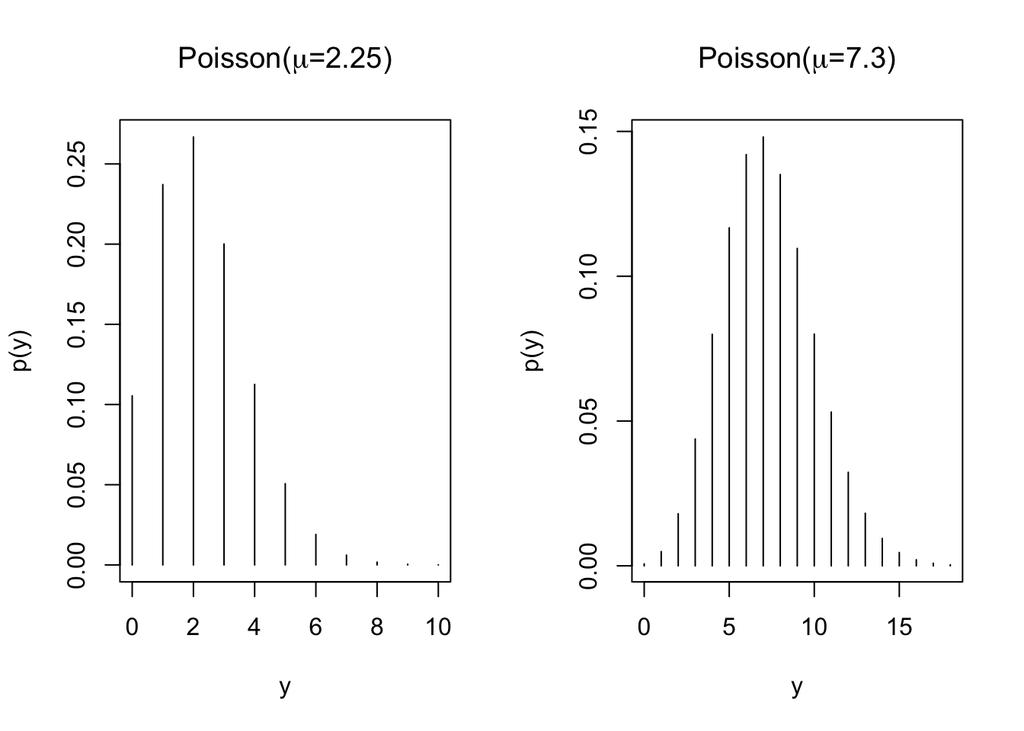

```r
###################################################
opar <- par(mfrow=c(1,2))
plot(0:10, dpois(0:10,2.25), type="h", xlab="y", ylab="p(y)",
     main=expression(paste("Poisson(", mu, "=2.25)")))
plot(0:18, dpois(0:18,7.3), type="h", xlab="y", ylab="p(y)",
     main=expression(paste("Poisson(", mu, "=7.3)")))
```

```r
par(opar)
```